# Epidemiology

- Study in population
- Distribution of diseases
- Determinants of diseases
- Use of that information to benefit and improve public health

# Environmental Epidemiology

- Environment as the setting of diseases
- Environment as the cause of diseases
- How do we study diseases and health outcomes in specific environmental setting

# Measures of Epidemiology

- Measures of distribution
- Measures of determinants
- Study designs to achieve these measures

# Measures of distribution

- Prevalence of diseases and health outcomes
- Incidence of diseases and health outcomes
- Standardised mortality and morbidity
- Study designs that allow us to establish these measures
- Which measures are most commonly used in environmental epidemiological studies

# Measures of determinants

- Rate Ratio and Relative Risk estimates
- Odds Ratio
- Hazard Ratio
- Attributable risk %
- Population attributable risk %
- Study designs that allow us to establish these measures

# Common environmental epidemiological study designs

- Ecological time series studies
- Cross-section surveys
- Case control studies
- Panel studies
- Cohort studies

# Prevalence of diseases

## Which city has more disease? (these are fictitious cities)

| City | Number of people with disease |
| --- | --- |
| Rimmarton | 350 |
| Fenmalton | 400 |

# Prevalence of diseases

## Which city has higher disease prevalence?

[output not shown]

# Prevalence

- Provides a proportion of the disease/outcome
- Need a base population for comparison
- It is a one-time measure, measured at a GIVEN point in time

# Incidence

## Imagine we study the city of Rimmarton for 5 years (2013-2017) and studied the trend of disease D (we measure the data at the end of the year, 31st December)

| Year | Population-at-risk | Number of people with disease D | Incidence Rate |
| --- | --- | --- | --- |
| 2013 | 1000 | 10 | 100 |
| 2014 | 990 | 12 | 121.2 |
| 2015 | 978 | 22 | 224.9 |
| 2016 | 956 | 20 | 209.2 |
| 2017 | 936 | 24 | 256.4 |

# Features of incidence rates

- Incidence is a rate, there is an element of time associated with it
- Incidence is about new cases
- The base population of incidence is with people who are disease free to start with
- Concept of person time
- 1 person followed for 1 year = 1 person-year
- 10 people followed for 1 year = 10 person-years
- 1 person followed for 10 years = 10 person-years

# Questions:

- What was the total person-years for this data?
- In terms of person-years over 5 years, what is the cumulative incidence rate?
- At the end of 2017, what is the prevalence of disease D in this population?

# What is the difference between incidence and prevalence?

# What happens when two populations are different?

| Age in years | Population_City_A | Number_with_disease | Population_city_b | Number_with_disease |
| --- | --- | --- | --- | --- |
| < 20 | 1000 | 20 | 600 | 30 |
| 20-39 | 1200 | 32 | 700 | 42 |
| 40-59 | 600 | 16 | 1200 | 12 |
| 60-79 | 200 | 8 | 600 | 6 |
| > 80 | 150 | 16 | 50 | 2 |
| Total | 3150 | 92 | 3150 | 92 |

- The two population structures are different
- Otherwise, the crude prevalence estimates are same for both populations
- Are the rates truly same?

# Age-specific and age-standardised rates

| Age in years | Prevalence in City A | Prevalence in City B |
| --- | --- | --- |
| < 20 | 200 | 500 |
| 20-39 | 266.67 | 600 |
| 40-59 | 266.67 | 100 |
| 60-79 | 400 | 100 |
| >= 80 | 1066.67 | 400 |

- Age-specific prevalence is different between the two cities although the crude prevalence is same
- City B has higher prevalence among the younger people while lower prevalence among the older population
- To compare the true rates of these two cities, we age-standardise the rates

# Age-standardisation

- In age standardisation, we use a standard population
- Multiply the age-specific rates with population count in each age-band
- Sum up the numbers to obtain the age-standardised prevalence (or incidence)

# We use a standardised population

- The WHO SEGI is a standard population
- You can make up any population that you think you can use

# A sample standard population

| Age in years | Standard population count |
| --- | --- |
| < 20 | 1000 |
| 20-39 | 1500 |
| 40-59 | 2500 |
| 60-79 | 1000 |
| >= 80 | 500 |

# Apply this population to our cities and we calculate the standard rates

| Age in years | Age-specific rate for city A | std count | Age-specific rate for B | Std Count |
| --- | --- | --- | --- | --- |
| < 20 | 200 | 20 | 500 | 50 |
| 20-39 | 266.67 | 40 | 600 | 90 |
| 40-59 | 266.67 | 67 | 100 | 25 |
| 60-79 | 400 | 40 | 100 | 10 |
| >= 80 | 1066.67 | 53 | 400 | 20 |

# Calculations from the standardised morbidity table

- The total number of diseased persons in standardised population for City A: 220
- The total number of diseased persons in standardised population for City B: 195
- These are also referred to as standardised morbidity rates for City A and City B (in this case)
- These are expressed in the form of standardised morbidity ratios: 1.12
- Indicates City A has higher burden of disease than City B

# What do these measurements indicate in environmental epidemiology?

- Prevalence estimates help us to understand the current state of the illnesses in a community
- Incidence figures help us to understand how fast the diseases are spreading
- Age-standardised rates help us to understand how disease statistics compare across time and countries, cities, communities

# Measures of association (Relative Risk estimates)

- Rate Ratio
- Odds Ratio

# Association between damp housing and chest infections

- Cold and damp housing can cause pneumonia: chest infection
- Imagine you are studying two groups of people: one group live in cold and damp houses (damp house group)
- Another group live in houses that are airy and sunny (dry house group)
- You want to test if living in cold and damp houses lead to chest infection
- You study 1000 people from each type of household for 5 years
- Thus, you study 5000 person-years from each household
- Imagine, that other than one group living in damp houses and the other group living in dry houses
- The group members are similar in every other aspect (age, gender, SES, ...)

# Results of your study

- Among the damp housing group, you find 150 people over 5 years to suffer from chest infection
- Among the dry house group, you find 50 people over 5 years who reported having chest infection
- What is the incidence of chest infection among the damp house group?
- What is the incidence of chest infection among the dry house group?
- What can you say about the association between damp housing and chest infection?

# Results of your study: Excess risk (continued)

| Participants | Number with chest infection | Person-years | Incidence rate per 10000 py |
| --- | --- | --- | --- |
| Damp housing | 150 | 5000 | 300 |
| Dry housing | 50 | 5000 | 100 |

# Results from your study (what do the figures indicate)

- Incidence of chest infection among those in damp houses: 300 per 10,000 person-years
- Incidence of chest infection among those in dry houses: 100 per 10, 000 person-years
- Excess risk of chest infection among those who live in damp houses: 200 per 10, 000 py
- We express this in the form of Ie - I0
- Excess risk is also known as 'Attributable Risk'
- This tells us that out of 300 per 10k-py who had chest infection who lived in damp houses, damp housing itself accounted for 200 cases
- Therefore Attributable Risk % = 200 / 300 = 66.7%
- 66.7% of the chest infection among those who lived in damp houses is accounted for by damp housing conditions

# Results of your study: Rate Ratio

| Participants | Number with chest infection | Person-years | Incidence rate per 10000 py |
| --- | --- | --- | --- |
| Damp housing | 150 | 5000 | 300 |
| Dry housing | 50 | 5000 | 100 |

# Results from your study, what does rate ratio mean?

- Incidence of chest infection among those who lived in damp houses: 300 per 10k py
- Incidence of chest infection among those who lived in dry houses: 100 per 10 py
- Ratio of such incidences: 300 / 100 = 3.0
- This tells us those who lived in damp houses were 3 times more likely to suffer from chest infection than those who lived in dry houses
- This measure is known as RR (Relative Risk or Rate Ratio)

# How do we find out Attributable risk from RR

- Formula: (RR - 1) / RR
- In our case we have RR = 3.0
- Therefore, our Attributable Risk: (3 - 1) / 3 = 2/3 = 66.7%
- You can see that this is the same figure as the one we discussed while using excess risk
- Use this formula when you can only get RR estimates

# How do we use Attributable Risk?

- Attributable Risk tells us what proportion of the outcome/disease is accounted for by the exposure
- It helps when we think of different types of exposures that lead to the same outcome
- We have talked about damp housing leading to chest infection
- You also think of indoor smoking/environmental tobacco smoke (ETS) leads to chest infection
- Let's say you run a similar study and find the RR between ETS and chest infection to be 6.5
- What is the Attributable Risk% (Answer: 84.6%)
- So among those who suffer from indoor smoking/ETS exposure, ETS accounts for 84% of chest infection!

# How do we use Attributable Risk to benefit public health?

- Let's say 20% people are exposed to damp housing condition
- We have estimated the RR between damp housing and chest infection to be 3.0
- This gives us an attributable risk % of 66.7
- If we were to convert ALL damp housing to dry housing (i.e., remove the exposure ENTIRELY), by how much we can reduce the risk of chest infection?
- That would be 20% * 66.7% = 13.3%
- This figure is referred to as population attributable risk % and tell us that if damp housing were to be removed ENTIRELY

# Relationship of Attributable Risk % and public health benefits

| Prevalence of exposure | Attributable Risk % | By how much disease will be reduced |
| --- | --- | --- |
| 20% | 66.7% | 13.34% |
| 25% | 66.7% | 16.67% |
| 30% | 66.7% | 20% |
| 35% | 66.7% | 23% |

- This shows that the more common the prevalence, for the same relative risk, the more the benefits to the public health if we can remove the source of exposure

# Alternative measure of Relative Risk: Odds Ratio

- What happens when the disease or outcome is a rare disease?
- For example, a disease such as cancer or birth defect
- A rare disease: 1 in 10, 000 or rarer
- A prospective study, where you can start with healthy people with or without exposure and wait for health outcomes is impractical
- Here you sample from people with and without disease

# Example of an Environmental Tobacco Smoke and Lung Cancer Study

- You want to test that exposure to environmental tobacco smoke can cause lung cancer
- You sample 200 people who were diagnosed with lung cancer from a hospital
- These are your 'cases'
- From the same hospital but a different ward, you sample another 200 people who did not have a diagnosis of lung cancer
- These are your controls
- From both groups, you took history of their exposure to ETS and classified the history of ETS exposure as heavy exposure versus low levels of exposure and want to compare

# Results from the ETS and lung cancer study

| Status of exposure to ETS | Cases (200) | Controls (200) |
| --- | --- | --- |
| Heavy Exposure to ETS | 140 | 30 |
| Low exposure to ETS | 60 | 170 |
| Total | 200 | 200 |

# Results from the ETS and lung cancer study (continued...)

- Chance of heavy exposure for cases = 140 / 200
- Chance of Low exposure for cases = 60 / 200
- Odds of heavy exposure for cases = chance of heavy exposure / chance of low exposure = 140 / 60
- Chance of heavy exposure for controls = 30
- Chance of low exposure for controls = 170
- Odds of heavy exposure for controls = chance of heavy exposure / chance of low exposure = 30 / 170
- Odds Ratio of heavy exposure for cases VERSUS controls = ( 140 / 60 ) / (30 / 170 ) = 13.2
- Odds Ratio is same as Rate Ratio for Rare Diseases!

# Summary (What have we learned so far)

- Epidemiology is the study of distribution and determinants of diseases in populations
- Measures of distribution include prevalence, incidence, and standardised rates that help us to compare groups of people
- Measures of association include rate ratio, odds ratio, attributable risk, and population attributable risk that help us to compare risks due to exposure variables
- We can use population attributable risk percentage to identify what public health actions can be of high value benefits for environmental exposure reduction
- Epidemiological studies are used to estimate these measures

```python
city_a_rate = np.array([200, 266.67, 266.67, 400, 1066.67])
std_count = np.array([1000, 1500, 2500, 1000, 500])
city_b_rate = np.array([500, 600, 100, 100, 400])
city_a_count = (city_a_rate / 10000) * std_count
city_a_count
city_b_count = (city_b_rate / 10000) * std_count
city_b_count
sum(city_b_count)
220 / 195
```

```
1.1282051282051282
```

```python
city_a_pop = np.array([1000, 1200, 600, 200, 150])
disease_a = np.array([20, 32, 16, 8, 16])
prev_a = disease_a * 10000 / city_a_pop
prev_a

city_b_pop = np.array([600, 700, 1200, 600, 50])
disease_b = np.array([30, 42, 12, 6, 2])
prev_b = disease_b * 10000 / city_b_pop
prev_b
```

```
array([500., 600., 100., 100., 400.])
```

```python
import pandas as pd
import numpy as np
import matplotlib.pyplot as plt

city = ['Rimmarton', 'Fenmalton']
deaths = [350, 400]

d = {'city': ['Rimmarton', 'Fenmalton'],
     'deaths': [350, 400] }

df = pd.DataFrame(data = d)
df['population'] = [1000, 1200]
df['prev_death'] = df['deaths'] * 100 / df['population']
df_html = df.to_html
20+32 + 16 + 8 + 16
600+700+1200+600+50
30+42+12+6+2
```

```
92
```

```python
d2 = {
    'year': ['2013', '2014', '2015', '2016', '2017'],
    'pop_at_risk': [1000, 990, 978, 956, 936],
    'disease_d': [10, 12, 22, 20, 24]

}

df2 = pd.DataFrame(data = d2)
df2['annual_incidence'] = df2['disease_d'] * 10000/df2['pop_at_risk']
df2

# sum(df2['disease_d'])
```

|  | year | pop_at_risk | disease_d | annual_incidence |
| --- | --- | --- | --- | --- |
| 0 | 2013 | 1000 | 10 | 100.000000 |
| 1 | 2014 | 990 | 12 | 121.212121 |
| 2 | 2015 | 978 | 22 | 224.948875 |
| 3 | 2016 | 956 | 20 | 209.205021 |
| 4 | 2017 | 936 | 24 | 256.410256 |

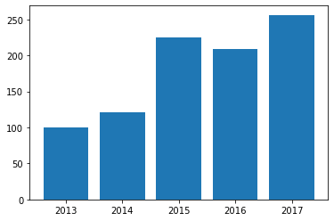

```python
plt.bar(df2['year'], df2['annual_incidence'])
plt.savefig('barplot.png')
```